# Week 1 Overview

September 28, 2014

## To Learn

Technologies:

- version control using **Git**
- project manage at **Github**
- publish web pages in **markdown**
- program in **Python**: arcpy module for ArcGIS functions; looping, variables…
- program in **R**: open-source, cross-platform; embed chunks of R in markdown: Rmarkdown
- publish web maps: **Leaflet javascript**, **ArcGIS Online**

Conservation analysis:

- **siting wind farms**
- building **species distribution models**
- assessing an **ecosystem service** (coastal protection)

## Motivation

## Why Git?

[figure not shown]

## Why Python?

[figure not shown]

## Why R?

[figure not shown]

## Specifics

## Git / Github Flow

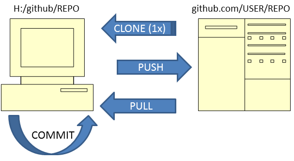

Division of labor:

- git performs these actions
- github stores repositories online

Other: **BRANCH**, **FORK**

Permissions:

- ucsb-bren/esm296-4f: pull only (no push privileges)
- USER/courses: push and pull

## Git / Github Features

GOOD:

- **text** formats (txt, r, py, md…)
- **backup** to offsite archive, and **rewind** changes
- **document** changes of code and files with issues and messages
- **collaborate** with others and **publish** to web site

BAD:

- **binary** formats (eg docx, pdf, shp…)
- **big** files (limits: 1GB per repository, 100MB per file)

## Folder Structure

So your local file structure will look like this:

**`H:/`**

- **`github/esm296-4f`**  
  read-only repo for course
- **`github/courses/esm296-4f`**  
  read-write personal `courses` repo containing `esm296-4f` folder
- **`esm296-4f`**  
  personal workspace for working through labs and everything else, especially for big data files

## Cool Features of Github

## Github: Track Changes View

**Track Changes View** with "Rendered" button to view differences between versions of a text file: additions in green, removals in red strikethrough.

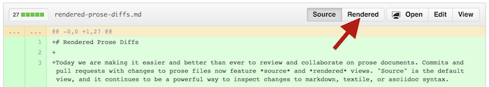

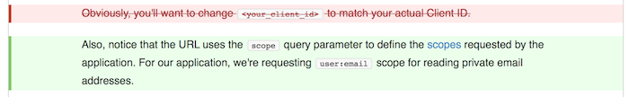

## Github: CSV View

**CSV View** allows for on the fly tabular view, searching for text, and linking to specific rows of data.

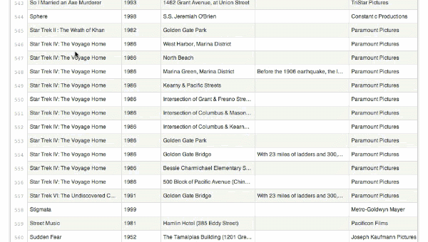

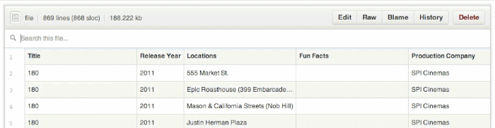

## Github: GeoJSON

**Geographic View** of GeoJSON renders automatically as a map.

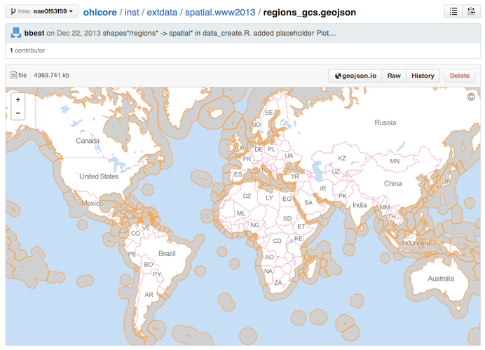

## Examples

National Center for Ecological Analysis and Synthesis (NCEAS)  
Open Science for Synthesis 2014: Software Skills Training for Early Career Scientists  
github.com/nceas/training

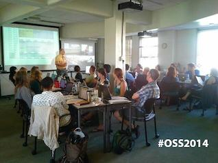

[Scientific writing: the online cooperative](http://www.nature.com/news/scientific-writing-the-online-cooperative-1.16039) - Nature (01 October 2014)  
*Collaborative browser-based tools aim to change the way researchers write and publish their papers.*

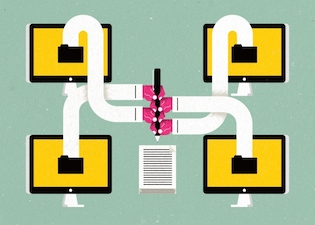

## Lab

[**Lab 1**](https://rawgit.com/ucsb-bren/esm296-4f/master/wk1/lab1.html): Wind Energy Lab